# Oferta laboral y salario para un Economista de la UNAM

2022-06-10

### **Oferta laboral y salario para un Economista de la UNAM**

Espejel Retiz Santiago

Flores Cedillo Francisco

**Sin duda una de las carreras que más importancia tiene a nivel mundial es la carrera de Economía, en México tenemos alrededor de 256 mil personas con formación económica incluyendo finanzas, banca y seguros según una estadística realizada por el INEGI en 2020.**

[figure not shown]

**La población en México durante en 2020 se encontraba en un aproximado de 128.9 millones de habitantes, por lo tanto las personas afines a una carrera económica representaban para el 2020 solo un 0.19% relativo a la población total del país.**

**Esto nos hace plantearnos muchas preguntas sobre si elegir una carrera económica sea la mejor decisión en cuanto a un fin monetario y laboral se refiere. En este artículo responderemos algunas incógnitas centrando nuestra investigación en específico en la licenciatura en Economía de una de las mejores universidades del país, la Universidad Nacional Autónoma de México.**

**Pero antes de empezar con los datos, debemos responder las siguientes preguntas:**

**¿A qué se dedica un economista?**

**¿ Cuáles son las funciones o cargos que este puede desempeñar?**

**¿ Cuáles son las características que un economista posee?**

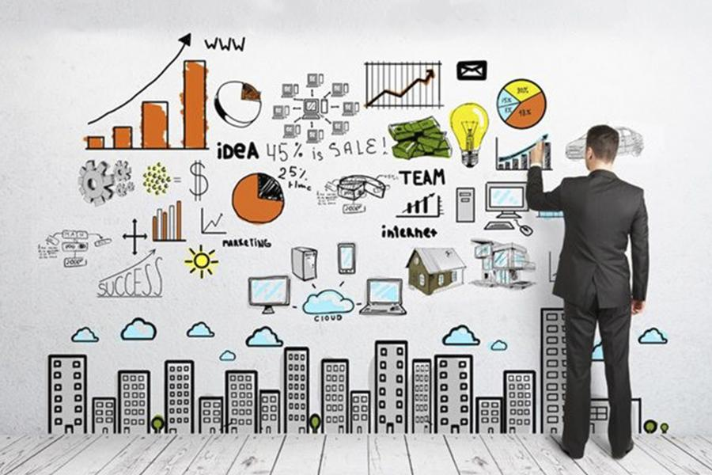

**Cuando se menciona la carrera de economía, lo primero que se viene a la mente es dinero, bancos, acciones, bolsa de valores, todos estos conceptos asociados a la carrera económica son correctos sin embargo la carrera de Economía abarca diferentes aspectos que muchas personas desconocen pero que no están lejos de la primera imagen que tienen acerca de la carrera. Por lo cual aclararemos este punto.**

**La Economía es una ciencia social que busca satisfacer las necesidades de un individuo mediante el uso correcto de los recursos cuando estos suelen ser escasos.**

**Una de las carreras más demandadas en las universidades mexicanas, y más en la UNAM, es la Licenciatura en Economía. Esta profesión cuenta con una excelente salida laboral para todos aquellos economistas que buscan un puesto de trabajo lo antes posible. Por lo tanto, si se desea cursar la licenciatura en economía podrás optar a estos empleos:**

- **Servicios profesionales en secretarías de Estado, organizaciones y empresas públicas y privadas.**
- **Consultor económico en entidades financieras, tales como bancos, aseguradoras y casas de bolsa.**
- **Profesor en institutos de educación superior y de investigación.**

**Existen empresas públicas y privadas en México y el extranjero, que poseen convenios con la UNAM, por lo que los estudiantes egresados, e incluso los que están en el séptimo o décimo semestre de la carrera, podrán optar por un puesto laboral gracias a la Bolsa de Trabajo que tiene esta universidad.**

**Un economista con una sólida formación teórico-práctica podrá ser un asesor de las micro, pequeñas, medianas y grandes empresas. Actualmente, uno de los principales empleadores del economista son las consultorías públicas y privadas.**

**El mercado laboral del economista requiere del manejo de herramientas cuantitativas, administrativas y financieras, un uso adecuado de la informática, conocimientos del idioma base (inlges) pero se puede enriquecer más su conocimiento con algún otro idioma extra, el título profesional y además que este profesionista se mantenga actualizado mediante el estudio de diplomados, maestrías y doctorados.**

**La Facultad de Economía es una plural, diversa y activa comunidad universitaria compuesta por 8,678 personas, de las cuales 7,173 son estudiantes, 1,250 integran el personal académico y 255 son trabajadoras y trabajadores administrativos y/o de base. Casi el 95% de las y los estudiantes son de licenciatura (escolarizada, abierta y a distancia), mientras que poco más del 5% son de posgrado (especializaciones, maestría y doctorado). Del total de nuestra población de estudiantes, el 33% son mujeres y el 67% son hombres**

#### **Encuesta realizada a los egresados de la carrera de Economía del 2014 (74 entrevistados)**

**La Situación laboral de los egresados a 4 años de haber concluido los estudios**

| Situación.Laboral.Actual | Femenino | Masculino | Total |
| --- | --- | --- | --- |
| Con empleo | 23 | 39 | 62 |
| Sin empleo | 2 | 2 | 4 |
| Sin buscar | 2 | 6 | 8 |
| TOTAL | 27 | 47 | 74 |

Tabla 1

**El 84% de los encuestados está trabajando y el 5% está buscando trabajo, es decir, el 89% participa en la actividad económica del país y el 11% restante no lo hace por diferentes razones. Podemos observar que no existe algun patron de empleados o desempleados, es decir, no se observan diferencias por género en el porcentaje de egresados que están incorporados a la fuerza laboral, 93% de las mujeres y 87% de los hombres, en la proporción de los que están buscando empleo 7% de las mujeres y 4% de los hombres, la diferencia no es significativa.**

**De los que están en busca de empleo, las causas que con mayor frecuencia señalan por las que no lo han encontrado son: por un lado, la falta de ofertas (75%) y porque perdieron su trabajo (25%). El 11% de los egresados que actualmente no están en el mercado laboral, están ocupados realizando otras actividades, principalmente estudiar (88%).**

| X | X.1 |
| --- | --- |
| Participan en las actividades economicas |  |
| 89.2% de los egresados |  |
|  | 92.6% de las mujeres |
|  | 87.2% de los hombres |
| 90.3% señala que su trabajo está entre "muy" y "medianamente" relacionado con su profesión |  |
| 50% trabaja en el sectir privado |  |
| 93.5% trabaja tiempo completo |  |
| 72.5% están satisfechos o muy satisfechos con su trabajo. |  |
| 54.5% considera que su preparacion para el trabajo fue "muy bueno" |  |

| Cuantos.están.trabajando | X |
| --- | --- |
| Si, permanente | 70.30% |
| Si, eventual | 13.50% |
| No, y en busca | 5.40% |
| No, y sin buscar | 10.80% |

**Las ramas económicas donde trabajan los egresados son: electricidad, agua y suministro de gas (2%), construcción (5%), industrias manufactureras (5%), comercio al por mayor (2%), comercio al por menor (2%), transporte, correos y almacenamiento (3%), información en medios masivos (3%), servicios financieros y de seguros (18%), servicios profesionales, científicos y técnicos (3%), servicios de apoyo a los negocios, manejo de desecho y servicios de remediación. (2%), servicios de salud (2%), servicios educativos (10%), servicios de esparcimiento, cultural, deportivos y otros centros recreativos (2%), actividades de gobierno, organismos internacionales y extraterritoriales (37%) y otra (3%). Con respecto a la dedicación al trabajo, el 94% laboran tiempo completo. El 85% trabajan como empleados y el 6% en autoempleo, ya sea como propietarios o en la práctica privada de su profesión. El 85% trabajan en la Ciudad de México, el 6% en el Estado de México y el 6% restante en otros estados.**

**¿A cuánto ascienden sus ingresos? La media de los ingresos de los egresados que trabajan tiempo completo es de $21,708.04. En promedio los hombres que trabajan tiempo completo tienen ingresos de $24,926.47 y las mujeres $16,734.09. El ingreso mínimo es de $6,000.00 y el máximo de $95,000.00**

| X | Marco.muestral.278..muestra.74 | X.1 |
| --- | --- | --- |
| Ingreso por sexo | Media |  |
|  | Tiempo Completo | Medio tiempo |
| Mujeres | $16,734 |  |
| Hombres | $24,926 | $9,750 |
| Total de la muestra | $21,708 | $9,750 |

**Fuente: Programa de Vinculación con los Egresados de la UNAM, PVEU.**

**Encuesta 2015-2016 a los cuatro años del egreso. http://www.pveu.unam.mx/encuesta/01/submenu.php**

#### **Encuesta realizada a los egresados de la carrera de Economía del 2018**

| X | Sector.Laboral.en.que.Trabaja | X.1 |
| --- | --- | --- |
|  | Facultad de Economía - Economía - 2018 |  |
| Sector laboral en que trabaja | Frecuencia | Frecuencia Relativa |
| Publico | 243 | 50.73 |
| Privado | 236 | 49.27 |
| No trabaja/ no contestó | 0 | 0 |
|  | 479 | 100 |

**El sector en el que desarrolla el economista es variado, ya que al ser una ciencia tan completa podría desenvolverse en distintos ámbitos del campo laboral así sean públicos o privados; en la siguiente tabla nos muestran el sector al que pertenece una población de economistas del 100%, pues es casi pareja la cifra. En la primera columna tenemos los sectores y en las dos restantes la frecuencia y la frecuencia relativa; en el sector público tenemos que un poco más del 50% de los economistas pertenecen a este, mientras que en el sector privado es un 49.27% quienes pertenecen a este. Vemos un muy ligero contraste entre ambos sectores.**

| ingresos.mensuales | X | X.1 |
| --- | --- | --- |
| Facultad de Economia- Economia- 2018 |  |  |
| Ingresos mensuales (salarios minimos) | Frecuencia | Frecuencia reativa |
| 1 o menos | 32 | 6.68 |
| 1 a 2 | 55 | 11.48 |
| 2 a 4 | 113 | 23.59 |
| 4 a 6 | 108 | 22.55 |
| 6 a 8 | 59 | 12.32 |
| 8 a10 | 30 | 6.26 |
| mas de 10 | 82 | 17.12 |

[output cut: 2 more lines]

**Respecto a la ocupación que tienen los economistas en el lugar donde laboran, podemos encontrar una gran variedad, pues el ser egresados de la carrera de economía les permite desenvolverse en ámbitos y ocupaciones variadas. En la primer columna tenemos las diez ocupaciones principales en las que se desempeñan los economistas, y con el porcentaje más alto que es del 30.27% tenemos que los economistas cumplen una función como empleados de confianza en sus trabajos, posteriormente le siguen los empleados de base con un 25.26% y así sucesivamente, hasta que tenemos a los dueños de negocios propios con una frecuencia relativa del 3.55% y los trabajadores independientes con 3.97%. Como en la anterior tabla hay un contraste muy notable, pero de forma más positiva, pues si bien no todos se desempeñan o dedican a los mismo ámbitos, al menos la mayoría obtiene algún empleo para poder generar ingresos con ayuda de su carrera.**

```r
datos1<-read.csv("tabla8.csv")
reactable(datos1)
```

| Principal.preocupacion.en.su.trabajo | X | X.1 |
| --- | --- | --- |
| Facultad de Economia- Economia- 2018 |  |  |
| Principal preocupacion en su trabajo | Frecuencia | Frecuencia relativa |
| Funcionario | 84 | 17.54 |
| Dueños de negocios | 17 | 3.55 |
| Profesores de educacion basica | 5 | 1.04 |
| Profesores de nivel superior | 32 | 6.68 |
| Profesor posgrado/investigador | 7 | 1.46 |
| Empleado de confianza | 145 | 30.27 |
| Empleado de base | 121 | 25.26 |
| Trabajador por su cuenta | 19 | 3.97 |

[output cut: 3 more lines]

[**https://www.estadistica.unam.mx/egreso/index.php?plantel=008&carrera=306&anio=2018&sexo=0**](https://www.estadistica.unam.mx/egreso/index.php?plantel=008&carrera=306&anio=2018&sexo=0) **Portal Estadistica Universitaria**